ANLT 224_01 - Data Wrangling

Copyright © Trang Vu 2020

Trang Vu - 989357826  
HW Week 4 Insights from Web Scraping

# Getting Insight from the Movie Theatrical Market

## Objective and Background Information

In this project, I would like to wrangle the data from a special source by scraping a webpage named the *numbers.com.* Their market analysis is built on The Numbers' unique categorization system, which uses six different criteria to identify a movie such as genres, production methods, mppaarating,theme,and so on. Their Domestic Market is defined as the North American movie territory (consisting of the United States, Canada, Puerto Rico and Guam).I would like to conduct data mining on web page utilizing *beautiful soup* libary and method, cleaning and retrieving the data and table in the best format for better exploration and analyzation for the next parts. Upon the finding, I will focus on the highlighted of the data based on their statistical information, their up and down in the theotrical movie industry and tickets sold throughout the year, especially the most current years. Furthermore, multiple linear regression model will be utilized upon findings for launching prediction model for recommendation toward boosting the movie tickets sold. I would like to see what is the vulnerability and insight that I could recommend to distributors and stakeholders to improve their sales and tickets sold each year and in the upcoming years, and whether there is relationship that strongly correlate and affects the sales of a particular top movies over the years. Moving along with mining and finding insights, I would want to visualize the data found to provide an detailed picture toward helping distributors and stakeholders in movie industry have a comprehensive view of this sector to acknowledge their direction and navigate through the market with the proper strategy and capture the trending categorization of the movie market.

## 1. Data Mining

First of all, let's import necessary packages and tool to read the data. We will import the package and then pass on the whole string (HTML content) to a method for parsing.

```python
import warnings
warnings.filterwarnings("ignore")
```

```python
from bs4 import BeautifulSoup
import bs4
import pandas as pd
import numpy as np

import requests
response = requests.get('https://www.the-numbers.com/market/')


movie = BeautifulSoup(response.text, 'html.parser')
```

```python
type(movie)
```

```
bs4.BeautifulSoup
```

```python
#dir(movie)
```

```python
#print(movie.prettify())
```

Let's try to retrieve one element of the web page.

```python
movie.link
```

```
<link href="/resources/the-numbers-desktop-combined.css" rel="stylesheet" type="text/css"/>
```

Let's try to retrieve another element.

```python
movie.link.next_sibling.next_sibling
```

```
<link href="https://m.the-numbers.com/market/" media="only screen and (max-width: 640px)" rel="alternate"/>
```

```python
txt_dump=movie.text
```

```python
type(txt_dump)
```

```
str
```

```python
print(txt_dump[10000:10200])
```

```
4,916


2010
Toy Story 3
Kids Fiction
Digital Animation
Original Screenplay
Adventure
G
Walt Disney
$415,004,880
$479,175,469
52,598,844


2011
Harry Potter and the Deathly Hallows: Part II
Fantasy
An
```

*Now, after some exploration of the data. Let's retrieve the information in the website for analysis.*

### 1.1 All the table tittles

Since this web page has several table, our first task is to find all the heading tittle of these tables and then we will decide further which table we will retrieve. After inspecting the page, we could see that all the tittle of those table are under h1 and/or h2 tag. Let's use that to retrieve all the table's names.

```python
tittle1 = movie.find_all('h2')
tittle2 = movie.find_all('h1')
```

```python
# Exclude all the html tag and get text only for each results element of beautiful soup
tittle01 = []
for line in tittle1:
    tittle01.append(line.get_text())
```

```python
# We have the tittle under h1 tag in here
tittle01
```

```
['Annual Ticket Sales']
```

```python
# Exclude all the html tag and get text only for each results element of beautiful soup
tittle02 = []
for line in tittle2:
    tittle02.append(line.get_text())
# We have the tittle under h1 tag in here
```

```python
tittle_tol = tittle01 + tittle02
tittle_tol.pop(1)
tittle_tol.pop(9)
tittle_tol.pop(9)
tittle_tol
```

```
['Annual Ticket Sales',
 'Number of Wide Releases Each Year',
 'Top Movie of Each Year',
 'Top-Grossing Distributors 1995 to 2020',
 'Top-Grossing Genres 1995 to 2020',
 'Top-Grossing MPAA Ratings 1995 to 2020',
 'Top-Grossing Sources 1995 to 2020',
 'Top-Grossing Production Methods 1995 to 2020',
 'Top-Grossing Creative Types 1995 to 2020',
 'Most Anticipated Movies',
 'Trending Movies',
 'Trending People']
```

Now that we have all the name, let's choose which tables that I would like to retrieve. I would like to retrieve *Annual Ticket Sales, Number of Wide Releases Each Year, Top Movie of each Year*

### 1.2 Retrieve Annual Ticket Sales table

Our first task is to find the tables's location in the HTML script.

```python
# Create a function to capture all the next sibling but for specific filter of tag.
def next_tag(tag_element):
    tag_element = tag_element.next_sibling
    while not isinstance(tag_element, bs4.Tag):
        tag_element = tag_element.next_sibling
    return(tag_element)
# Inspecting the website, we acknowledge the fact that the table is following after a "class" heading
#introducing about
# that table. Let's utilize this factor to retrieve the table using our beautiful soup "movie".

for subclass in movie.find_all('h1', text='Domestic Movie Theatrical Market Summary 1995 to 2020'):
    element = next_tag(subclass)
    if element.name == 'table':
         element = element.next_sibling
```

Let's take a look at the length of the element that we just retrieved.

```python
len(element)
```

```
8
```

Let's also take a look at the type of the element that we just retrieved.

```python
type(element)
```

```
bs4.element.Tag
```

As we can wee, this is not done yet and we still have to look into these element to find a specific target table and separate them into different element of a list.

```python
# Let's create a list first that store each beautiful soup element in 8 element in the soup results
list = []
for i in element:
    list.append(i)
```

```python
#list[1]
```

```python
# After inspecting the list, I could see that list[1] has all the targeted table
# Now let's create a seconf list, this time only loop through list[1],find all table and append to a new list.
tag = []
for subclass in list[1].find_all('table'):
    tag.append(subclass)
```

```python
len(tag)
```

```
8
```

```python
# Let's take a look at the second element in the list
# comment out to avoid the length of the output
#tag[1]
```

Awesome, we are able to retrieve all the table we needed. Now, let retrieve each table one by one. Let's retrieve different elements in the dataset by extracting features from this table, starting with the year.

```python
names = tag[0].find_all("th")
```

```python
# Remove all the html code
new_name = []
for line in names:
    new_name.append(line.get_text())
```

```python
new_name
```

```
['Year',
 'Tickets SoldTotal Box OfficeTotal InflationAdjusted Box OfficeAverageTicket Price',
 'Total Box Office',
 'Total InflationAdjusted Box Office',
 'AverageTicket Price']
```

```python
# Cleaning strings
new_name[1] = 'Tickets Sold'
new_name[3] = "Total Inflation Adjusted Box Office"
```

```python
# We got the column name for our first table data
new_name
```

```
['Year',
 'Tickets Sold',
 'Total Box Office',
 'Total Inflation Adjusted Box Office',
 'AverageTicket Price']
```

Awesome, now that we have all the name of the column here. Let's retrieve data table of this first table.

```python
# Utilzing td tag to has all body cells of the table in a list
rows = tag[0].find_all("td")
table_data = []
for row in rows:
    table_data.append(row.get_text())
```

```python
display(table_data[0])
```

```
'2020'
```

```python
range(len(tag[0].find_all("tr")))
```

```
range(0, 27)
```

```python
# list of length in which we have to split
# we will split the list base on the column number and row number
# len(tag[0].find_all("tr")) will return the row number
# len(new_name) will return column number
length_to_split = []
for i in range(len(tag[0].find_all("tr"))):
    length_to_split.append(len(new_name))
```

```python
length_to_split.pop(26)
```

```
5
```

```python
from itertools import islice
from itertools import accumulate
```

```python
#Inputt = iter(table_data)
Output = [table_data[x - y: x] for x, y in zip(
          accumulate(length_to_split), length_to_split)]
```

```python
Output
```

```
[['2020', '1,060,168,828', '$9,658,138,025', '$9,658,138,025', '$9.11'],
 ['2019', '1,246,923,740', '$11,359,478,067', '$11,359,478,153', '$9.11'],
 ['2018', '1,311,323,188', '$11,946,156,764', '$11,946,156,943', '$9.11'],
 ['2017', '1,225,639,438', '$10,993,988,560', '$11,165,575,309', '$8.97'],
 ['2016', '1,301,658,904', '$11,259,352,764', '$11,858,112,611', '$8.65'],
 ['2015', '1,323,266,320', '$11,155,138,079', '$12,054,956,180', '$8.43'],
 ['2014', '1,257,400,618', '$10,272,966,196', '$11,454,919,630', '$8.17'],
 ['2013', '1,339,168,926', '$10,887,446,341', '$12,199,828,924', '$8.13'],
 ['2012', '1,381,106,440', '$10,993,610,207', '$12,581,879,666', '$7.96'],
 ['2011', '1,282,891,721', '$10,173,333,767', '$11,687,143,588', '$7.93'],
 ['2010', '1,328,549,023', '$10,482,254,025', '$12,103,081,605', '$7.89'],
 ['2009', '1,418,567,388', '$10,639,257,284', '$12,923,123,576', '$7.50'],
 ['2008', '1,358,041,408', '$9,750,739,371', '$12,371,757,232', '$7.18'],
 ['2007', '1,420,036,680', '$9,769,854,914', '$12,936,534,157', '$6.88'],
 ['2006', '1,398,738,283', '$9,161,738,221', '$12,742,505,757', '$6.55'],
 ['2005', '1,373,215,640', '$8,802,314,376', '$12,509,994,482', '$6.41'],
 ['2004', '1,495,647,988', '$9,287,975,958', '$13,625,353,184', '$6.21'],
 ['2003', '1,524,299,815', '$9,191,529,762', '$13,886,371,327', '$6.03'],
 ['2002', '1,576,438,339', '$9,159,108,550', '$14,361,353,263', '$5.81'],
 ['2001', '1,476,216,078', '$8,355,384,639', '$13,448,328,468', '$5.66'],
 ['2000', '1,397,460,079', '$7,532,311,479', '$12,730,861,331', '$5.39'],
 ['1999', '1,444,664,086', '$7,338,894,852', '$13,160,889,827', '$5.08'],
 ['1998', '1,443,827,003', '$6,771,549,637', '$13,153,263,987', '$4.69'],
 ['1997', '1,385,218,935', '$6,358,155,799', '$12,619,344,508', '$4.59'],
 ['1996', '1,305,169,274', '$5,768,848,969', '$11,890,048,751', '$4.42'],
 ['1995', '1,221,689,691', '$5,314,350,848', '$11,129,593,086', '$4.35']]
```

```python
import pandas as pd
dfObj = pd.DataFrame(Output)
dfObj.columns = new_name
```

```python
# Let's take a glance of our first table
dfObj.head()
```

|  | Year | Tickets Sold | Total Box Office | Total Inflation Adjusted Box Office | AverageTicket Price |
| --- | --- | --- | --- | --- | --- |
| 0 | 2020 | 1,060,168,828 | $9,658,138,025 | $9,658,138,025 | $9.11 |
| 1 | 2019 | 1,246,923,740 | $11,359,478,067 | $11,359,478,153 | $9.11 |
| 2 | 2018 | 1,311,323,188 | $11,946,156,764 | $11,946,156,943 | $9.11 |
| 3 | 2017 | 1,225,639,438 | $10,993,988,560 | $11,165,575,309 | $8.97 |
| 4 | 2016 | 1,301,658,904 | $11,259,352,764 | $11,858,112,611 | $8.65 |

### 1.3 Retrieve Number of Wide Releases Each Year

Go through the website, it is clearly to see that this website provides detail and comprehensive information about market analys in the theotrical movie market with real data and detailed criteria. Moving along, I would like to retrieve the second tables on the web page using our existed tool to learn about number of wide movie releases from different distributors each year.

```python
# utilize beautiful soup method find_all "th" tag for the column name
names2 = tag[1].find_all("th")
```

```python
# Create a list to store the element that we just retrieved
col_name = []
for line in names2:
    col_name.append(line.get_text())
```

```python
col_name
```

```
['Year',
 'Warner Bros',
 'Walt Disney',
 '20th Century Fox',
 'Paramount Pictures',
 'Sony Pictures',
 'Universal',
 'Total Major 6',
 'Total Other Studios']
```

```python
# Utilzing td tag to has all body cells of the table in a list
cells = tag[1].find_all("td")
table_data2 = []
for row in cells:
    table_data2.append(row.get_text())
```

```python
from itertools import accumulate

# list of length in which we have to split following the same method for 1.2
# utilizing tr tag and len(col_name)
length_to_split = []
for i in range(len(tag[1].find_all("tr"))):
    length_to_split.append(len(col_name))
Output2 = [table_data2[x - y: x] for x, y in zip(
          accumulate(length_to_split), length_to_split)]
```

```python
Output2.pop(26)
```

```
[]
```

```python
# Take a glance at our list
Output2[1]
```

```
['2019', '18', '10', '11', '9', '18', '21', '87', '44']
```

```python
dfObj2 = pd.DataFrame(Output2)
dfObj2.columns = col_name
```

```python
# Take a glance of our second table retrieved.
dfObj2.head()
```

|  | Year | Warner Bros | Walt Disney | 20th Century Fox | Paramount Pictures | Sony Pictures | Universal | Total Major 6 | Total Other Studios |
| --- | --- | --- | --- | --- | --- | --- | --- | --- | --- |
| 0 | 2020 | 17 | 9 | 1 | 17 | 15 | 26 | 85 | 43 |
| 1 | 2019 | 18 | 10 | 11 | 9 | 18 | 21 | 87 | 44 |
| 2 | 2018 | 19 | 10 | 11 | 10 | 16 | 20 | 86 | 58 |
| 3 | 2017 | 18 | 8 | 14 | 10 | 16 | 15 | 81 | 50 |
| 4 | 2016 | 17 | 12 | 16 | 12 | 16 | 22 | 95 | 46 |

### 1.4 Retrieve Top Movie of each Year Table

Lastly, I would like to utilize the same method to retrieve the last table. This table is established in the website as the top movie each year which does not only show cases the top movies but their categorization, their distributor and tickers sold, sales.

```python
# Utilize "th" tag to retrieve column name with beautiful soup
names3 = tag[2].find_all("th")
col_name3 = []
for line in names3:
    col_name3.append(line.get_text())
print(col_name3)
```

```
['Year', 'Movie', 'CategorizationCreative TypeProduction MethodSourceGenre', 'MPAARating', 'Distributor', 'Total for Year', 'Total in 2018 dollars', 'Tickets Sold']
```

```python
col_name3[2] = 'Categorization'
col_name3
```

```
['Year',
 'Movie',
 'Categorization',
 'MPAARating',
 'Distributor',
 'Total for Year',
 'Total in 2018 dollars',
 'Tickets Sold']
```

```python
# Utilzing td tag to has all body cells of the table in a list
cells3 = tag[2].find_all("td")
table_data3 = []
for row in cells3:
    table_data3.append(row.get_text())
```

```python
# Create a for loop to remove all the \n
out = []
for i in range(len(table_data3)):
        out.append(table_data3[i].replace("\n", ","))
```

```python
from itertools import accumulate

# list of length in which we have to split following the same method for 1.2, 1.3
# utilizing tr tag and len(col_name)
length_to_split = []
for i in range(len(tag[2].find_all("tr"))):
    length_to_split.append(len(col_name3))

Output3 = [out[x - y: x] for x, y in zip(
          accumulate(length_to_split), length_to_split)]
```

```python
# Remove one empty elements.
Output3.pop(26)
```

```
[]
```

```python
# Now let's make a table out of it
import pandas as pd
dfObj3 = pd.DataFrame(Output3)
dfObj3.columns = col_name3
```

```python
dfObj3.head()
```

|  | Year | Movie | Categorization | MPAARating | Distributor | Total for Year | Total in 2018 dollars | Tickets Sold |
| --- | --- | --- | --- | --- | --- | --- | --- | --- |
| 0 | 1995 | Batman Forever | Super Hero,Live Action,Based on Comic/Graphic ... | PG-13 | Warner Bros. | $184,031,112 | $385,407,678 | 42,306,002 |
| 1 | 1996 | Independence Day | Science Fiction,Live Action,Original Screenpla... | PG-13 | 20th Century Fox | $306,169,255 | $631,041,155 | 69,269,062 |
| 2 | 1997 | Men in Black | Science Fiction,Live Action,Based on Comic/Gra... | PG-13 | Sony Pictures | $250,650,052 | $497,477,550 | 54,607,854 |
| 3 | 1998 | Titanic | Historical Fiction,Live Action,Original Screen... | PG-13 | Paramount Pictures | $443,319,081 | $861,116,592 | 94,524,324 |
| 4 | 1999 | Star Wars Ep. I: The Phantom Menace | Science Fiction,Animation/Live Action,Original... | PG | 20th Century Fox | $430,443,350 | $771,917,102 | 84,732,942 |

## 3. Findings

In this part, I will dig deep into those tables that I have mined and wrangled from the web page. i would like to explore them and gain better look at their highlight and insight.

### 3.1 Findings part 1

Let's change our column name for better retrieving and let's get general information of this table.

```python
dfObj.columns = ["year","ticketsold","totalbox","infla_box","averagepr"]
```

```python
#dfObj = dfObj.drop(df.tail(0).index,inplace=True)
```

```python
dfObj.info()
```

```
<class 'pandas.core.frame.DataFrame'>
RangeIndex: 26 entries, 0 to 25
Data columns (total 5 columns):
year          26 non-null object
ticketsold    26 non-null object
totalbox      26 non-null object
infla_box     26 non-null object
averagepr     26 non-null object
dtypes: object(5)
memory usage: 1.1+ KB
```

As we could see, the data store in our first stable has data type as string. Let's clean it up and change the data type to int and float.

```python
dfObj.ticketsold = dfObj.ticketsold.apply(lambda x: x.replace('$',''))
dfObj.ticketsold = dfObj.ticketsold.apply(lambda x: x.replace(',',''))
```

```python
dfObj.ticketsold = dfObj.ticketsold.astype(int)
```

```python
dfObj.totalbox = dfObj.totalbox.apply(lambda x: x.replace('$',''))
dfObj.totalbox = dfObj.totalbox.apply(lambda x: x.replace(',','')).astype(int)
dfObj.infla_box = dfObj.infla_box.apply(lambda x: x.replace('$',''))
dfObj.infla_box = dfObj.infla_box.apply(lambda x: x.replace(',','')).astype(int)
dfObj.averagepr = dfObj.averagepr.apply(lambda x: x.replace('$',''))
dfObj.averagepr = dfObj.averagepr.apply(lambda x: x.replace(',','')).astype(float)
```

```python
dfObj.info()
```

```
<class 'pandas.core.frame.DataFrame'>
RangeIndex: 26 entries, 0 to 25
Data columns (total 5 columns):
year          26 non-null object
ticketsold    26 non-null int64
totalbox      26 non-null int64
infla_box     26 non-null int64
averagepr     26 non-null float64
dtypes: float64(1), int64(3), object(1)
memory usage: 1.1+ KB
```

```python
# Let's get statistic information of numeric value in this table
dfObj.describe()
```

|  | ticketsold | totalbox | infla_box | averagepr |
| --- | --- | --- | --- | --- |
| count | 2.600000e+01 | 2.600000e+01 | 2.600000e+01 | 26.000000 |
| mean | 1.357590e+09 | 9.322457e+09 | 1.236764e+10 | 6.931154 |
| std | 1.093400e+08 | 1.830687e+09 | 9.960871e+08 | 1.597892 |
| min | 1.060169e+09 | 5.314351e+09 | 9.658138e+09 | 4.350000 |
| 25% | 1.302536e+09 | 8.467117e+09 | 1.186610e+10 | 5.697500 |
| 50% | 1.365629e+09 | 9.704439e+09 | 1.244088e+10 | 7.030000 |
| 75% | 1.419669e+09 | 1.082540e+10 | 1.293318e+10 | 8.160000 |
| max | 1.576438e+09 | 1.194616e+10 | 1.436135e+10 | 9.110000 |

*Let's find out the top five years that have the most ticket sold.*

```python
dfObj.sort_values(by='ticketsold', ascending=False).head()
```

|  | year | ticketsold | totalbox | infla_box | averagepr |
| --- | --- | --- | --- | --- | --- |
| 18 | 2002 | 1576438339 | 9159108550 | 14361353263 | 5.81 |
| 17 | 2003 | 1524299815 | 9191529762 | 13886371327 | 6.03 |
| 16 | 2004 | 1495647988 | 9287975958 | 13625353184 | 6.21 |
| 19 | 2001 | 1476216078 | 8355384639 | 13448328468 | 5.66 |
| 21 | 1999 | 1444664086 | 7338894852 | 13160889827 | 5.08 |

As we could see from here, the top year has the most ticket sold being 2002, followed by 2003 and 2004. We could see that durin these years, the movie market raise rapidly while the inflation seem low and average price is comparatively low during these time. It looks like people were more enjoying going to movie theaters in the past compared to the present.

*Let's find out the top five years that have the least ticket sold.*

```python
dfObj.sort_values(by='ticketsold', ascending=True).head()
```

|  | year | ticketsold | totalbox | infla_box | averagepr |
| --- | --- | --- | --- | --- | --- |
| 0 | 2020 | 1060168828 | 9658138025 | 9658138025 | 9.11 |
| 25 | 1995 | 1221689691 | 5314350848 | 11129593086 | 4.35 |
| 3 | 2017 | 1225639438 | 10993988560 | 11165575309 | 8.97 |
| 1 | 2019 | 1246923740 | 11359478067 | 11359478153 | 9.11 |
| 6 | 2014 | 1257400618 | 10272966196 | 11454919630 | 8.17 |

Interestingly, in according to this result, we can see that the ticket sold are shown in the most recent year including 2020.According to the web page, figures for 2020 are at an annualized rate as an estimation in accordance to the data. From here, it is clear that during the most recent years of 2017 to 2019, the movie industry seem low on demand compare to the rest years, 2014 is also on the top 5 lowest tickets sold and it look like its ticket price is comparatively high as well. 1995 suppprisingly has the second lowest ticket sold with pretty average price. It could due to the fact that the economy and low in inflation during those time.

### 3.2 Findings part 2

Let's take a look and analyze our second tables. I would like to compare and base on my intial exploration and outcome of finding part 1 to dig deeper into this part to find relationship and correlation between differen features. Let's also change our column names in our second table to better retrieving the information.

```python
dfObj2.columns = ["year","warner_bros","walt_disney","twentycentury","paramount","sonypic","universal","total_major","total_other"]
```

```python
# Let's change all the data type to interger.
dfObj2.warner_bros = dfObj2.warner_bros.astype(int)
dfObj2.walt_disney = dfObj2.walt_disney.astype(int)
dfObj2.twentycentury = dfObj2.twentycentury.astype(int)
dfObj2.paramount = dfObj2.paramount.astype(int)
dfObj2.sonypic = dfObj2.sonypic.astype(int)
dfObj2.universal = dfObj2.universal.astype(int)
dfObj2.total_major = dfObj2.total_major.astype(int)
dfObj2.total_other = dfObj2.total_other.astype(int)
```

```python
# Let's get general information of our second tables
dfObj2.info()
```

```
<class 'pandas.core.frame.DataFrame'>
RangeIndex: 26 entries, 0 to 25
Data columns (total 9 columns):
year             26 non-null object
warner_bros      26 non-null int64
walt_disney      26 non-null int64
twentycentury    26 non-null int64
paramount        26 non-null int64
sonypic          26 non-null int64
universal        26 non-null int64
total_major      26 non-null int64
total_other      26 non-null int64
dtypes: int64(8), object(1)
memory usage: 1.9+ KB
```

Great! Now let's get statistic information of numeric value in this table.

```python
dfObj2.describe()
```

|  | warner_bros | walt_disney | twentycentury | paramount | sonypic | universal | total_major | total_other |
| --- | --- | --- | --- | --- | --- | --- | --- | --- |
| count | 26.000000 | 26.000000 | 26.000000 | 26.000000 | 26.000000 | 26.000000 | 26.000000 | 26.000000 |
| mean | 23.461538 | 15.538462 | 15.038462 | 12.538462 | 18.538462 | 17.000000 | 102.115385 | 33.846154 |
| std | 5.449629 | 5.449629 | 4.512035 | 2.469506 | 3.202883 | 3.784178 | 13.297600 | 11.069570 |
| min | 16.000000 | 8.000000 | 1.000000 | 8.000000 | 13.000000 | 10.000000 | 78.000000 | 19.000000 |
| 25% | 18.250000 | 11.000000 | 13.000000 | 10.250000 | 16.000000 | 14.250000 | 90.750000 | 25.000000 |
| 50% | 23.500000 | 13.500000 | 15.000000 | 12.500000 | 18.500000 | 17.000000 | 104.000000 | 30.500000 |
| 75% | 27.750000 | 20.750000 | 17.750000 | 14.000000 | 20.750000 | 20.000000 | 112.500000 | 42.750000 |
| max | 32.000000 | 25.000000 | 25.000000 | 17.000000 | 26.000000 | 26.000000 | 128.000000 | 58.000000 |

Take a look at mean, max and min, it is clear to see that warner bros has the highest mean and high significant different between min and max, followed by the rest which have comparative amount of movies released. There is a year that twenty century only release one movie, the minimum amount released of the rest are somewhat similar.

*Let's find out the top five years that have the most total_major wide release.*

```python
dfObj2.sort_values(by='total_major', ascending=False).head()
```

|  | year | warner_bros | walt_disney | twentycentury | paramount | sonypic | universal | total_major | total_other |
| --- | --- | --- | --- | --- | --- | --- | --- | --- | --- |
| 14 | 2006 | 26 | 17 | 25 | 13 | 26 | 21 | 128 | 31 |
| 24 | 1996 | 31 | 23 | 13 | 16 | 24 | 13 | 120 | 22 |
| 18 | 2002 | 32 | 23 | 15 | 16 | 20 | 13 | 119 | 21 |
| 13 | 2007 | 30 | 13 | 17 | 16 | 22 | 20 | 118 | 50 |
| 23 | 1997 | 31 | 22 | 12 | 16 | 22 | 11 | 114 | 22 |

```python
dfObj2.sort_values(by='warner_bros', ascending=False).head()
```

|  | year | warner_bros | walt_disney | twentycentury | paramount | sonypic | universal | total_major | total_other |
| --- | --- | --- | --- | --- | --- | --- | --- | --- | --- |
| 18 | 2002 | 32 | 23 | 15 | 16 | 20 | 13 | 119 | 21 |
| 24 | 1996 | 31 | 23 | 13 | 16 | 24 | 13 | 120 | 22 |
| 23 | 1997 | 31 | 22 | 12 | 16 | 22 | 11 | 114 | 22 |
| 13 | 2007 | 30 | 13 | 17 | 16 | 22 | 20 | 118 | 50 |
| 19 | 2001 | 30 | 16 | 16 | 14 | 17 | 10 | 103 | 25 |

We can see that warner bros has the highest total major wide release in 2002 , followed by 1996 and 1997. It looks like warner bros made a revolution in that year with the significant movies released and 2002 is also on top of the list with highest ticket sold in movie industry. It looks like 2002 is the year of warner bros and walt disney while twenty century, paramount and sonypic have such smaller amount of movies released. 2002 is seemed to be a year that has super high in ticket sold but small in price in ticket and large number of movies are released in that year.

During our first finding, there are a year that only one movie was released from twenty century. Let's take a look at that year to see what happened.

```python
dfObj2[dfObj2['twentycentury']== 1]
```

|  | year | warner_bros | walt_disney | twentycentury | paramount | sonypic | universal | total_major | total_other |
| --- | --- | --- | --- | --- | --- | --- | --- | --- | --- |
| 0 | 2020 | 17 | 9 | 1 | 17 | 15 | 26 | 85 | 43 |

It looks like 2020 are expected to have really low in term of movies released with twenty century distributor reaches the bottom. Let's also take a look at 1995 and 2017 since these two years are on the top list of lowest ticket sales in comparision to the other years.

```python
years = ["1995", "2017"]
dfObj2[dfObj2.year.isin(years)]
```

|  | year | warner_bros | walt_disney | twentycentury | paramount | sonypic | universal | total_major | total_other |
| --- | --- | --- | --- | --- | --- | --- | --- | --- | --- |
| 3 | 2017 | 18 | 8 | 14 | 10 | 16 | 15 | 81 | 50 |
| 25 | 1995 | 27 | 22 | 11 | 12 | 20 | 17 | 109 | 27 |

I would like to dig further into the relationship between the tickets sold and the average price and warner_bros release, total major wide release and total wide release. First of all, let's gather the total wide release each year by sum between total major and total other.

```python
total = []
total = dfObj2.total_major + dfObj2.total_other
```

```python
# Let's take a look of the total list that we have here.
total
```

```
0     128
1     131
2     144
3     131
4     141
5     126
6     125
7     120
8     132
9     136
10    126
11    141
12    152
13    168
14    159
15    137
16    138
17    129
18    140
19    128
20    131
21    132
22    126
23    136
24    142
25    136
dtype: int64
```

```python
# Let's do some normalization
from sklearn import preprocessing
import numpy as numpy
total_norm = preprocessing.scale(total)
totalmaj_norm = preprocessing.scale(dfObj2.total_major)
ticketsold_norm = preprocessing.scale(dfObj.ticketsold)
averag_norm = preprocessing.scale(dfObj.averagepr)
warner_bros_norm = preprocessing.scale(dfObj2.warner_bros)
```

Let's form it as a separate dataframe.

```python
big_list = [total_norm,totalmaj_norm,ticketsold_norm,averag_norm,warner_bros_norm]
```

```python
df = pd.DataFrame(
    {'total_wide': total_norm,
     'total_major': totalmaj_norm,
     'warner_bros': warner_bros_norm,
     'average_price': averag_norm,
     'ticket_sold':ticketsold_norm
    }
)
```

```python
df.head()
```

|  | total_wide | total_major | warner_bros | average_price | ticket_sold |
| --- | --- | --- | --- | --- | --- |
| 0 | -0.748581 | -1.312593 | -1.209165 | 1.390580 | -2.774016 |
| 1 | -0.466507 | -1.159211 | -1.022032 | 1.390580 | -1.032170 |
| 2 | 0.755814 | -1.235902 | -0.834900 | 1.390580 | -0.431522 |
| 3 | -0.466507 | -1.619356 | -1.022032 | 1.301229 | -1.230687 |
| 4 | 0.473740 | -0.545685 | -1.209165 | 1.096999 | -0.521660 |

```python
df.corr()
```

|  | total_wide | total_major | warner_bros | average_price | ticket_sold |
| --- | --- | --- | --- | --- | --- |
| total_wide | 1.000000 | 0.596035 | 0.282511 | -0.104066 | 0.184246 |
| total_major | 0.596035 | 1.000000 | 0.815607 | -0.755819 | 0.585432 |
| warner_bros | 0.282511 | 0.815607 | 1.000000 | -0.842102 | 0.632430 |
| average_price | -0.104066 | -0.755819 | -0.842102 | 1.000000 | -0.519109 |
| ticket_sold | 0.184246 | 0.585432 | 0.632430 | -0.519109 | 1.000000 |

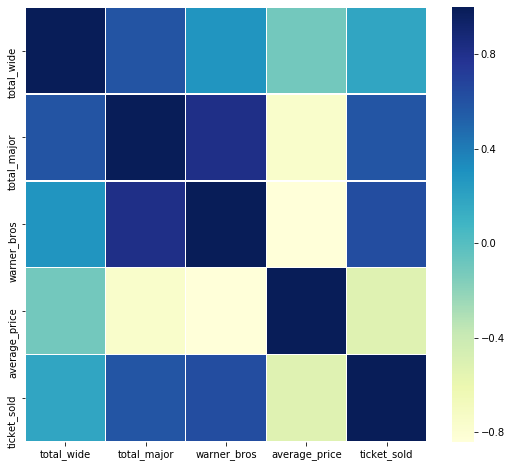

```python
# Let's check the correlation of this variables with the y variable being tickets sold.
import matplotlib.pyplot as plt
import seaborn as sns
corrmat = df.corr()
f, ax = plt.subplots(figsize =(9, 8))
sns.heatmap(corrmat, ax = ax, cmap ="YlGnBu", linewidths = 0.1)
```

```python
# import statsmodels
import statsmodels.api as sm
X = df[["warner_bros","average_price","total_major"]]
y = df[["ticket_sold"]]
model = sm.OLS(y, X).fit()
predictions = model.predict(X)
model.summary()
```

OLS Regression Results

| Dep. Variable: | ticket_sold | R-squared (uncentered): | 0.417 |
| --- | --- | --- | --- |
| Model: | OLS | Adj. R-squared (uncentered): | 0.341 |
| Method: | Least Squares | F-statistic: | 5.489 |
| Date: | Fri, 14 Feb 2020 | Prob (F-statistic): | 0.00540 |
| Time: | 18:12:33 | Log-Likelihood: | -29.873 |
| No. Observations: | 26 | AIC: | 65.75 |
| Df Residuals: | 23 | BIC: | 69.52 |
| Df Model: | 3 |  |  |
| Covariance Type: | nonrobust |  |  |

|  | coef | std err | t | P>\|t\| | [0.025 | 0.975] |
| --- | --- | --- | --- | --- | --- | --- |
| warner_bros | 0.5306 | 0.342 | 1.549 | 0.135 | -0.178 | 1.239 |
| average_price | 0.1005 | 0.303 | 0.332 | 0.743 | -0.526 | 0.727 |
| total_major | 0.2287 | 0.282 | 0.811 | 0.426 | -0.355 | 0.812 |

| Omnibus: | 4.669 | Durbin-Watson: | 0.743 |
| --- | --- | --- | --- |
| Prob(Omnibus): | 0.097 | Jarque-Bera (JB): | 3.142 |
| Skew: | -0.827 | Prob(JB): | 0.208 |
| Kurtosis: | 3.407 | Cond. No. | 4.26 |

Warnings:  
[1] Standard Errors assume that the covariance matrix of the errors is correctly specified.

### 3.3 Findings part 3 : Top Movie of each Year Table

In this part, let's dig deeper into table three to gain more insight about movie type, genere and the overall highlighted in the movie industry.

```python
dfObj3.columns = ["year","movie","categorization","mpaarating","distributor","totalyear","totalin2018","ticketsold"]
```

```python
# Let's change some data type to interger.
dfObj3.totalyear = dfObj3.totalyear.apply(lambda x: x.replace('$',''))
dfObj3.totalyear = dfObj3.totalyear.apply(lambda x: x.replace(',','')).astype(int)
dfObj3.totalin2018 = dfObj3.totalin2018.apply(lambda x: x.replace('$',''))
dfObj3.totalin2018 = dfObj3.totalin2018.apply(lambda x: x.replace(',','')).astype(int)
dfObj3.ticketsold = dfObj3.ticketsold.apply(lambda x: x.replace('$',''))
dfObj3.ticketsold = dfObj3.ticketsold.apply(lambda x: x.replace(',','')).astype(int)
```

```python
dfObj3.head()
```

|  | year | movie | categorization | mpaarating | distributor | totalyear | totalin2018 | ticketsold |
| --- | --- | --- | --- | --- | --- | --- | --- | --- |
| 0 | 1995 | Batman Forever | Super Hero,Live Action,Based on Comic/Graphic ... | PG-13 | Warner Bros. | 184031112 | 385407678 | 42306002 |
| 1 | 1996 | Independence Day | Science Fiction,Live Action,Original Screenpla... | PG-13 | 20th Century Fox | 306169255 | 631041155 | 69269062 |
| 2 | 1997 | Men in Black | Science Fiction,Live Action,Based on Comic/Gra... | PG-13 | Sony Pictures | 250650052 | 497477550 | 54607854 |
| 3 | 1998 | Titanic | Historical Fiction,Live Action,Original Screen... | PG-13 | Paramount Pictures | 443319081 | 861116592 | 94524324 |
| 4 | 1999 | Star Wars Ep. I: The Phantom Menace | Science Fiction,Animation/Live Action,Original... | PG | 20th Century Fox | 430443350 | 771917102 | 84732942 |

*Taking a look at the table, I could see a different features and different aspects that we could analyze from here to gain insight and dig deeper into this movie industry. Let's first sort the table in accordance to the ticket sold. Let's seet what is going on specifically in the top 5 years that has the most tickets sold.*

```python
pd.options.display.max_colwidth = 100
```

```python
dfObj3.sort_values(by='ticketsold', ascending=False).head()
```

|  | year | movie | categorization | mpaarating | distributor | totalyear | totalin2018 | ticketsold |
| --- | --- | --- | --- | --- | --- | --- | --- | --- |
| 3 | 1998 | Titanic | Historical Fiction,Live Action,Original Screenplay,Thriller/Suspense | PG-13 | Paramount Pictures | 443319081 | 861116592 | 94524324 |
| 24 | 2019 | Avengers: Endgame | Super Hero,Animation/Live Action,Based on Comic/Graphic Novel,Action | PG-13 | Walt Disney | 858373000 | 858372997 | 94223161 |
| 20 | 2015 | Star Wars Ep. VII: The Force Awakens | Science Fiction,Animation/Live Action,Original Screenplay,Adventure | PG-13 | Walt Disney | 742208942 | 802078699 | 88043765 |
| 4 | 1999 | Star Wars Ep. I: The Phantom Menace | Science Fiction,Animation/Live Action,Original Screenplay,Adventure | PG | 20th Century Fox | 430443350 | 771917102 | 84732942 |
| 17 | 2012 | The Avengers | Super Hero,Animation/Live Action,Based on Comic/Graphic Novel,Action | PG-13 | Walt Disney | 623357910 | 713415897 | 78311295 |

As we could see in the results here, 1998 stands out the most with their most popular movies named Titanic. Until now, there are no other movie could break the record of Titanic with 94524324 tickets sold and total sales for the year in 2018 dollars being 861116592 dollars. The type and categorization of movie are historical fiction, live action, original screenplay, thriller/suspense types of movie with mpaarating being PG-13.The distributor of this movie is Paramount. Follow the first ranking in the chart is Avengers : Endgame which is just released last year (2019) with comparatively high in tickets sold and sales as well. This type of movie are Super Hero,Animation/Live Action,Based on Comic/Graphic Novel,Action. As we can see, Avengers: Endgame almost breaks the records of Titanic with alternatively high in ticket sold and sales. With this movie, Walt Disney could prove their high strength in producing animation combining with live action, bringing out comic/graphic noval into life. 2015 follows closely with another products of Walt Disney with the Star Wars Ep. VII with Science Fiction,Animation/Live Action,Original Screenplay,Adventure while 1999 has orginal first episode version of Star Wars with the same type but from 20th Century Fox. Walt Disney once again showcased their talent in remaking movie and transforming science fiction aling with animation and live action versus adventure. Ranking fifth in the chart with total ticket solds in 2012, the Avengers of Walt Disney has the type of super hero, animation/live action with base of comic/ graphic novel. It also has really high in sales and comparatively high in tickets sold but not as high as Star Wars and Avengers from the same distributor: Walt Disney. In general, it looks like Walt Disney is on top of the list with science fiction movies in the most recent years while Paramount and 20th Century Fox had their best amount of ticket sold in a long time ago.

Now that we have an overview of the most popular movie over the years. Let's learn more about categorical features and see which kinds of categorization, mpaarating and distributor appear the most in this chart over the year.

```python
dfObj3.categorization.mode()
```

```
0     Science Fiction,Animation/Live Action,Original Screenplay,Adventure
1    Super Hero,Animation/Live Action,Based on Comic/Graphic Novel,Action
dtype: object
```

```python
dfObj3.mpaarating.mode()
```

```
0    PG-13
dtype: object
```

```python
dfObj3.distributor.mode()
```

```
0    Walt Disney
dtype: object
```

Looking at these results, we could see that there are two types/ caegorization of movie that has the same most frequency in the chart with the former being Science Fiction,Animation/Live Action,Original Screenplay,Adventure and the latter being Super Hero,Animation/Live Action,Based on Comic/Graphic Novel,Action. It is noticeable that these science fiction and super hero type of movies are really popular over the years. Animation and live action is the most common producction methods to produce high quality and most popular movie over the years. PG-13 means some material maybe inappropriate for children under 13, which showcased the fact that most popular movies over the year used strong and sometime sensitive effect to catch viewers and create strong effect, which is sensitive for certain young ages but gain large amount of popular population age. This can illustrate the fact that though some certain movies restricted age but they still attract large amount of viewers in wider age and older population based on their contents.They would want to target on that instead of younger population for those most sold ticket movies in the theaters. And lastly, it is no doubt that Walt Disney stands out the most as the distributor having the highest frequency in the top movie dataframe over the year, which showcases the powerful and the smart startegy of Walt Disney that keep them on top over many years in comparision to other distributors.

*Now let's grab these information together to see what it appears like in the dataframe with the most popular categorization, mpaarating and distributor.*

```python
# Filter Science Fiction,Animation/Live Action,Original Screenplay,Adventure
# with PG-13 and Walt Disney
top = dfObj3[(dfObj3.categorization =='Science Fiction,Animation/Live Action,Original Screenplay,Adventure')
             & (dfObj3.mpaarating =='PG-13') & (dfObj3.distributor =='Walt Disney')]
```

```python
top
```

|  | year | movie | categorization | mpaarating | distributor | totalyear | totalin2018 | ticketsold |
| --- | --- | --- | --- | --- | --- | --- | --- | --- |
| 20 | 2015 | Star Wars Ep. VII: The Force Awakens | Science Fiction,Animation/Live Action,Original Screenplay,Adventure | PG-13 | Walt Disney | 742208942 | 802078699 | 88043765 |
| 22 | 2017 | Star Wars Ep. VIII: The Last Jedi | Science Fiction,Animation/Live Action,Original Screenplay,Adventure | PG-13 | Walt Disney | 517218368 | 525290890 | 57660910 |

```python
# Filter Super Hero,Animation/Live Action,Based on Comic/Graphic Novel,Action
# with PG-13 and Walt Disney
top2 = dfObj3[(dfObj3.categorization =='Super Hero,Animation/Live Action,Based on Comic/Graphic Novel,Action')
             & (dfObj3.mpaarating =='PG-13') & (dfObj3.distributor =='Walt Disney')]
```

```python
top2
```

|  | year | movie | categorization | mpaarating | distributor | totalyear | totalin2018 | ticketsold |
| --- | --- | --- | --- | --- | --- | --- | --- | --- |
| 17 | 2012 | The Avengers | Super Hero,Animation/Live Action,Based on Comic/Graphic Novel,Action | PG-13 | Walt Disney | 623357910 | 713415897 | 78311295 |
| 18 | 2013 | Iron Man 3 | Super Hero,Animation/Live Action,Based on Comic/Graphic Novel,Action | PG-13 | Walt Disney | 408992272 | 458292689 | 50306552 |
| 19 | 2014 | Guardians of the Galaxy | Super Hero,Animation/Live Action,Based on Comic/Graphic Novel,Action | PG-13 | Walt Disney | 333055258 | 371374953 | 40765637 |
| 24 | 2019 | Avengers: Endgame | Super Hero,Animation/Live Action,Based on Comic/Graphic Novel,Action | PG-13 | Walt Disney | 858373000 | 858372997 | 94223161 |

Let's see what other distributor were doing with the same types of super hero or science fiction movies.

```python
# Other distributors - Science Fiction,Animation/Live Action,Original Screenplay,Adventure
top3 = dfObj3[(dfObj3.categorization =='Science Fiction,Animation/Live Action,Original Screenplay,Adventure')
             & (dfObj3.mpaarating =='PG-13') & (dfObj3.distributor !='Walt Disney')]
```

```python
top3
```

|  | year | movie | categorization | mpaarating | distributor | totalyear | totalin2018 | ticketsold |
| --- | --- | --- | --- | --- | --- | --- | --- | --- |
| 10 | 2005 | Star Wars Ep. III: Revenge of the Sith | Science Fiction,Animation/Live Action,Original Screenplay,Adventure | PG-13 | 20th Century Fox | 380270577 | 540446942 | 59324582 |

It looks like 20th Century Fox did followed the algorithm and produced another version and episode of StarWars with their winning in 2005 with that original screen play and science fiction/ animation production and concept, that result the most promising later on to the movie industry that Walt Disney has followed and gain a lot of popularity and popularity for their movies.

```python
# Other distributors - Super Hero,Animation/Live Action,Based on Comic/Graphic Novel,Action
top4 = dfObj3[(dfObj3.categorization =='Super Hero,Animation/Live Action,Based on Comic/Graphic Novel,Action')
             & (dfObj3.mpaarating =='PG-13') & (dfObj3.distributor !='Walt Disney')]
```

```python
top4
```

|  | year | movie | categorization | mpaarating | distributor | totalyear | totalin2018 | ticketsold |
| --- | --- | --- | --- | --- | --- | --- | --- | --- |

It looks like this combination of categorization are only achieved by Walt Disney so far while other distributors might try different types of combination and production into producing their movies.

*Now let's focus on categorization features by filtering and grouping different layer to gain more insight of different categorization and how they affects tickets sold and winning factors.*

```python
# Let's do some value counts for categorization
dfObj3['categorization'].value_counts()
```

```
Science Fiction,Animation/Live Action,Original Screenplay,Adventure           4
Super Hero,Animation/Live Action,Based on Comic/Graphic Novel,Action          4
Kids Fiction,Digital Animation,Original Screenplay,Adventure                  3
Super Hero,Live Action,Based on Comic/Graphic Novel,Action                    3
Fantasy,Animation/Live Action,Based on Fiction Book/Short Story,Adventure     2
Super Hero,Live Action,Based on Comic/Graphic Novel,Adventure                 2
Kids Fiction,Live Action,Based on Fiction Book/Short Story,Adventure          1
Historical Fiction,Live Action,Original Screenplay,Thriller/Suspense          1
Contemporary Fiction,Live Action,Original Screenplay,Action                   1
Kids Fiction,Digital Animation,Based on Fiction Book/Short Story,Adventure    1
Historical Fiction,Live Action,Based on Theme Park Ride,Adventure             1
Science Fiction,Live Action,Original Screenplay,Adventure                     1
Science Fiction,Live Action,Based on Comic/Graphic Novel,Adventure            1
Science Fiction,Animation/Live Action,Based on TV,Action                      1
Name: categorization, dtype: int64
```

```python
# Let's do some value counts for distributors
dfObj3['distributor'].value_counts()
```

```
Walt Disney           11
Sony Pictures          4
Warner Bros.           4
20th Century Fox       3
Paramount Pictures     2
Dreamworks SKG         1
Universal              1
Name: distributor, dtype: int64
```

Walt Disney is no doubt on top of the games with 11 times of frequencies of top movies, following by Warner Bros. and Sony Pictures, 20th Century Fox and Paramount rank third and fourth respectively in term of their frequency for top movies over the year. In the last past, we have learned that Warner Bros. has the most movie released over the year but it does not make it to be a best movie producer and distributor while walt disney has lesser movies released each year but their quality and investment in the movies conquer all. Universal and Dreamworks SKG supprisingly ranks last in this competition in term of their frequencies and their likely to be the winner.

```python
# Let's gather sum of all tickets sold for each distributors for top movie over the years up until current.
a = dfObj3['ticketsold'][dfObj3['distributor'] == 'Walt Disney'].sum()
b = dfObj3['ticketsold'][dfObj3['distributor'] == 'Warner Bros.'].sum()
c = dfObj3['ticketsold'][dfObj3['distributor'] == 'Sony Pictures'].sum()
d = dfObj3['ticketsold'][dfObj3['distributor'] == '20th Century Fox'].sum()
e = dfObj3['ticketsold'][dfObj3['distributor'] == 'Paramount Pictures'].sum()
f = dfObj3['ticketsold'][dfObj3['distributor'] == 'Dreamworks SKG'].sum()
g = dfObj3['ticketsold'][dfObj3['distributor'] == 'Universal'].sum()

# Let's make a Series out of it.
dis_df = pd.Series(
    {'Walt Disney': a,
     'Warner Bros': b,
     'Sony Picture': c,
     '20th Century Fox': d,
     'Paramount Pictures':e,
     'Dreamworks SKG':f,
     'Universal':g
    }

)
dis_df.sort_values(ascending=False)
```

```
Walt Disney           715940223
Warner Bros           217383454
20th Century Fox      213326586
Sony Picture          192353719
Paramount Pictures    148139240
Dreamworks SKG         71050925
Universal              47006948
dtype: int64
```

Walt Disney has the most significant amount of ticket solds for their best movies while Warner Bros and 20th Century Fox are approximately the same with slightly different in term of total ticket solds. Sony Picture follows up closely with more than 192 million. Paramount has much smaller amount of ticket sold for their best movie with 148 million.Dreamworks and Universal have much lower in term of sales summary for their best movies over the year.

```python
# Let's do the same thing with top six categorizations in the top movies table.
a2 = dfObj3['ticketsold'][dfObj3['categorization'] == 'Science Fiction,Animation/Live Action,Original Screenplay,Adventure'].sum()
b2 = dfObj3['ticketsold'][dfObj3['categorization'] == 'Super Hero,Animation/Live Action,Based on Comic/Graphic Novel,Action'].sum()
c2 = dfObj3['ticketsold'][dfObj3['categorization'] == 'Kids Fiction,Digital Animation,Original Screenplay,Adventure'].sum()
d2 = dfObj3['ticketsold'][dfObj3['categorization'] == 'Super Hero,Live Action,Based on Comic/Graphic Novel,Adventure'].sum()
e2 = dfObj3['ticketsold'][dfObj3['categorization'] == 'Super Hero,Live Action,Based on Comic/Graphic Novel,Action'].sum()
f2 = dfObj3['ticketsold'][dfObj3['categorization'] == 'Fantasy,Animation/Live Action,Based on Fiction Book/Short Story,Adventure'].sum()

# Let's make a Series out of it.
dis_df2 = pd.Series(
    {'Science Fiction with live action': a2,
     'Super Hero animation with live action': b2,
     'Kids Fiction with digital animation': c2,
     'Super Hero with theme Adventure': d2,
     'Super Hero with theme Action':e2,
     'Fantasy with animation and adventure':f2

    }

)
dis_df2.sort_values(ascending=False)
```

```
Science Fiction with live action         289762199
Super Hero animation with live action    263606645
Super Hero with theme Action             193106831
Kids Fiction with digital animation      165155358
Super Hero with theme Adventure          119082605
Fantasy with animation and adventure     101121800
dtype: int64
```

Science fiction and super hero animation with live action are the top two production method that attracts the most tickets over the years. Kids Fiction with digital animation is much different and lower than the top two methods with their summary in sales being around 150 millions.Fantasy with animation only help the distributors gain much smaller sales for their best movies with only around 100 millions.

```python
# Let's also compare the sales of these distributors with 2018 cash in summary.
a3 = dfObj3['totalin2018'][dfObj3['distributor'] == 'Walt Disney'].sum()
b3 = dfObj3['totalin2018'][dfObj3['distributor'] == 'Warner Bros.'].sum()
c3 = dfObj3['totalin2018'][dfObj3['distributor'] == 'Sony Pictures'].sum()
d3 = dfObj3['totalin2018'][dfObj3['distributor'] == '20th Century Fox'].sum()
e3 = dfObj3['totalin2018'][dfObj3['distributor'] == 'Paramount Pictures'].sum()
f3 = dfObj3['totalin2018'][dfObj3['distributor'] == 'Dreamworks SKG'].sum()
g3 = dfObj3['totalin2018'][dfObj3['distributor'] == 'Universal'].sum()

# Let's make a Series out of it.
dis_df3 = pd.Series(
    {'Walt Disney': a3,
     'Warner Bros': b3,
     'Sony Picture': c3,
     '20th Century Fox': d3,
     'Paramount Pictures':e3,
     'Dreamworks SKG':f3,
     'Universal':g3
    }

)
dis_df3.sort_values(ascending=False)
```

```
Walt Disney           6522215430
Warner Bros           1980363266
20th Century Fox      1943405199
Sony Picture          1752342388
Paramount Pictures    1349548477
Dreamworks SKG         647273927
Universal              428233296
dtype: int64
```

Let's finally look at the relationship between categorization and its distributor in accordance to year and tickets sold to see how well they are doing with different concepts and movies over the latest 15 years.

```python
# Let's subset the dataframe first
# I want to look at catgeorization, distribution, year and ticketsold
dfObj3_sub = dfObj3[['movie','categorization', 'distributor', 'year','ticketsold']]
```

```python
# Let's use group by to group the categorizatiton and year, distributor together accordingly and see how different
# catgeorization has in term of yer, distributor and ticket sold.
# in the latest 15 years until current.
dfObj3_sub.year = dfObj3.year.astype(int)
dfObj3_10years = dfObj3_sub[(dfObj3_sub.year >= 2005)]
dfObj3_10years.sort_values(by='ticketsold', ascending = True).groupby(['categorization','year','distributor']).first()
```

| categorization | year | distributor | movie | ticketsold |
| --- | --- | --- | --- | --- |
| Contemporary Fiction,Live Action,Original Screenplay,Action | 2020 | Sony Pictures | Bad Boys For Life | 18663260 |
| Fantasy,Animation/Live Action,Based on Fiction Book/Short Story,Adventure | 2011 | Warner Bros. | Harry Potter and the Deathly Hallows: Part II | 48046812 |
| Historical Fiction,Live Action,Based on Theme Park Ride,Adventure | 2006 | Walt Disney | Pirates of the Caribbean: Dead Manâs Chest | 64628368 |
| Kids Fiction,Digital Animation,Original Screenplay,Adventure | 2010 | Walt Disney | Toy Story 3 | 52598844 |
|  | 2016 | Walt Disney | Finding Dory | 56219140 |
| Science Fiction,Animation/Live Action,Based on TV,Action | 2009 | Paramount Pictures | Transformers: Revenge of the Fallen | 53614916 |
| Science Fiction,Animation/Live Action,Original Screenplay,Adventure | 2005 | 20th Century Fox | Star Wars Ep. III: Revenge of the Sith | 59324582 |
|  | 2015 | Walt Disney | Star Wars Ep. VII: The Force Awakens | 88043765 |
|  | 2017 | Walt Disney | Star Wars Ep. VIII: The Last Jedi | 57660910 |
| Super Hero,Animation/Live Action,Based on Comic/Graphic Novel,Action | 2012 | Walt Disney | The Avengers | 78311295 |
|  | 2013 | Walt Disney | Iron Man 3 | 50306552 |
|  | 2014 | Walt Disney | Guardians of the Galaxy | 40765637 |
|  | 2019 | Walt Disney | Avengers: Endgame | 94223161 |
| Super Hero,Live Action,Based on Comic/Graphic Novel,Action | 2008 | Warner Bros. | The Dark Knight | 73955652 |
|  | 2018 | Walt Disney | Black Panther | 76845177 |
| Super Hero,Live Action,Based on Comic/Graphic Novel,Adventure | 2007 | Sony Pictures | Spider-Man 3 | 48914288 |

```python
# Let's also look at the old years to see how style in movie production and trend differently during those years.
dfObj3_pastyears = dfObj3_sub[(dfObj3_sub.year <= 2000)]
dfObj3_pastyears.sort_values(by='ticketsold', ascending = True).groupby(['categorization','year','distributor']).first()
```

| categorization | year | distributor | movie | ticketsold |
| --- | --- | --- | --- | --- |
| Historical Fiction,Live Action,Original Screenplay,Thriller/Suspense | 1998 | Paramount Pictures | Titanic | 94524324 |
| Kids Fiction,Live Action,Based on Fiction Book/Short Story,Adventure | 2000 | Universal | How the Grinch Stole Christmas | 47006948 |
| Science Fiction,Animation/Live Action,Original Screenplay,Adventure | 1999 | 20th Century Fox | Star Wars Ep. I: The Phantom Menace | 84732942 |
| Science Fiction,Live Action,Based on Comic/Graphic Novel,Adventure | 1997 | Sony Pictures | Men in Black | 54607854 |
| Science Fiction,Live Action,Original Screenplay,Adventure | 1996 | 20th Century Fox | Independence Day | 69269062 |
| Super Hero,Live Action,Based on Comic/Graphic Novel,Action | 1995 | Warner Bros. | Batman Forever | 42306002 |

In the past, it looks like Disney did not gain the popularity at that time yet compared to other big distributors. Distributors at those time seem to focus more on adventure theme with live action and original screen play. Each year, the winnder seemed to have unique type of combination in term of movie genres and theme. Adventur theme are utilized to the max during those time.

## 4. Plots

### 4.1 Plot 1 - Line Graph

In this section, I would like to create a line graph to take a look at ticket sold and average price trend over the year.

```python
# tickets sold and average ticket price changes over the year
import plotly.graph_objects as go
import numpy as np
from plotly.subplots import make_subplots

# Create figure with secondary y-axis
fig2 = make_subplots(specs=[[{"secondary_y": True}]])

# Add traces
fig2.add_trace(go.Scatter(x=dfObj.year, y=dfObj.ticketsold,
                    mode='lines',
                    name='Tickets Sold'),secondary_y= False)
# Adding different lines representing average price over the years
fig2.add_trace(go.Scatter(x=dfObj.year, y=dfObj.averagepr,
                    mode='lines',
                    name='Average price'),secondary_y= True)

# Update layout
fig2.update_layout(
    title="Tickets sold over the year versus Average Price",
    xaxis_title="Year",
    yaxis_title="Ticket sold and average price",
    font=dict(
        family="Courier New, monospace",
        size=12,
        color="black"
    )
)


fig2.show()
```

[interactive chart not shown]

### 4.2 Plot 2 - Scatter plot

In this part, I would like to utilize scatter plot to illustrate the performance of different distributors over the year with their movies released.

```python
import plotly.graph_objects as go
import numpy as np

# Wide release each years for different distributors.
fig = go.Figure(data=go.Scattergl(
    x = dfObj2.year,
    y = dfObj2.warner_bros,
    mode='markers',
    name='Warner Bros',
    marker=dict(
        color='blue',
        colorscale='Viridis',
        line_width=1
    )
))
fig.add_trace(go.Scatter(x=dfObj2.year, y= dfObj2.walt_disney,
                    mode='markers',
                    name='Walt Disney'))
fig.add_trace(go.Scatter(x=dfObj2.year, y=dfObj2.twentycentury,
                    mode='markers',
                    name='20th Century'))
fig.add_trace(go.Scatter(x=dfObj2.year, y=dfObj2.paramount,
                    mode='markers',
                    name='Paramount'))
fig.add_trace(go.Scatter(x=dfObj2.year, y=dfObj2.sonypic,
                    mode='markers',
                    name='Sony'))
fig.add_trace(go.Scatter(x=dfObj2.year, y=dfObj2.universal,
                    mode='markers',
                    name='Universal'))
fig.add_trace(go.Scatter(x=dfObj2.year, y=dfObj2.total_other,
                    mode='markers',
                    name='Others'))


fig.update_layout(
    title="Wide release over the year of different distributors",
    xaxis_title="Year",
    yaxis_title="Wide release",
    font=dict(
        family="Courier New, monospace",
        size=12,
        color="black"
    )
)

fig.show()
```

[interactive chart not shown]

### 4.3 Plot 3 - Box Plot

In this part, I would like to pay closer attention to the distributors and their performance to see what potential and drawback that they have in accordance to their tickets sold and their sales in 2018 cash performance.

*Distributors versus ticketsold*

```python
dfObj3_pl2 = dfObj3[['distributor','ticketsold']]
```

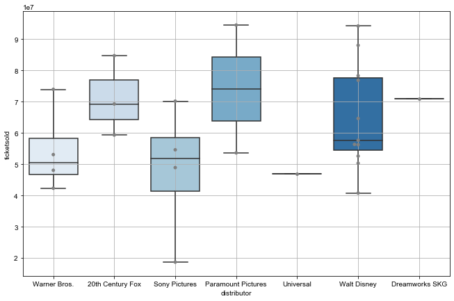

```python
# Create box plot with categorical data being distributor with ticketsold.
plt.figure(figsize=(11,7))
sns.boxplot(
    data=dfObj3_pl2,
    x='distributor',
    y='ticketsold',
    palette="Blues",showfliers=False)
sns.set_style("whitegrid")
ax = sns.swarmplot(x='distributor', y='ticketsold', data=dfObj3_pl2, color="grey")
ax.yaxis.grid(True) # Hide the horizontal gridlines
ax.xaxis.grid(True) # Show the vertical gridlines
```

*Distributor versus total sales in 2018 cash*

```python
dfObj3_pl3 = dfObj3[['distributor','totalin2018']]
```

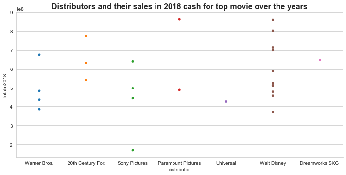

```python
# Ploting sea born with swarm style
sns.catplot(x='distributor', y='totalin2018', data=dfObj3_pl3.query("distributor != 3"), aspect=2,jitter=False)
plt.title('Distributors and their sales in 2018 cash for top movie over the years', weight='bold', fontsize=16)
```

This seaborn point plot also once again confirms the strong in distributing and winning viewer's attention with Walt Disney, followed by Warner Bros and Sony Pictures while 20th Centurey Fox and Paramount has comparatively high in their sales with their top movies but less distributed in the chart.

### 4.4 Plot 4 - Bar Graph

Let's focus on categorization of movies like their production method, genres and tickets sold over the decade to see the trending in viewer's tastes.

```python
# Categorizstion with tickets sold over the year
```

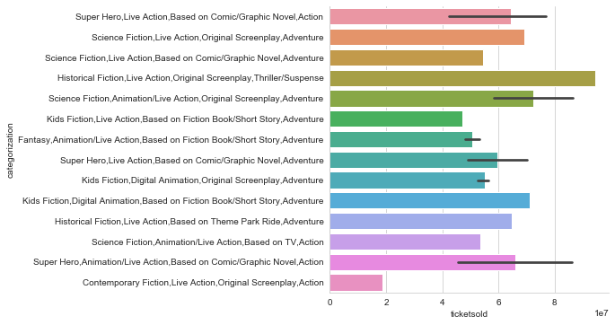

```python
# Plotting
sns.catplot(x="ticketsold",y="categorization",data=dfObj3,kind = "bar")
```

In this bar chart, historical fiction versus live action with original screenplay and thriller are on top of the bar chart with its most tickets sold. Meanwhile, super hero and science fiction are on the rise in the most current years with emphasizing on live acton and adventure screenplay. Animation method of producing movie is in the trend with a lof of categorization has this method and comparatively high in sales. Super Hero with Animation with live action and original screen play or comic novel are really on the trending lately. Meanwhile, contemporary Fiction and kid fiction theme tends to less attracts the viewers than the rest in the top movie througout the decades.

### 4.5 Plot 5 - Multiple Linear Regression

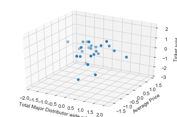

```python
# Plot the multiple linear regression out without the predicted value
import numpy as np
import matplotlib.pyplot as plt
from mpl_toolkits.mplot3d import Axes3D
# graph the data
fig = plt.figure(1)
ax = fig.add_subplot(111, projection='3d')
ax.scatter(X[['total_major']], X[['average_price']], y)
ax.set_xlabel('Total Major Distributor wide release')
ax.set_ylabel('Average Price')
ax.set_zlabel('Ticket sold')
```

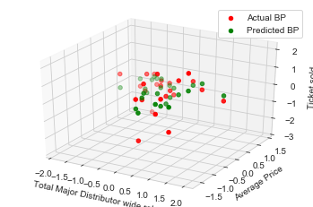

```python
# Plot the multiple linear regression out with the predicted value

#Use Linear Algebra to solve
a = np.linalg.solve(np.dot(X.T, X), np.dot(X.T, y))
predictedY = np.dot(X, a)

fig = plt.figure(2)
ax = fig.add_subplot(111, projection='3d')
ax.scatter(X[['total_major']], X[['average_price']], y, color='r', label='Actual BP')
ax.scatter(X[['total_major']], X[['average_price']], predictedY, color='g', label='Predicted BP')
ax.set_xlabel('Total Major Distributor wide release')
ax.set_ylabel('Average Price')
ax.set_zlabel('Ticket sold')
ax.legend()
plt.show()
```